# Superstore Data Analysis

Kevin Chong

2022-12-15

# Preamble

In this project, we are analyzing the superstore dataset, and we want to determine which features impact profit either positively or negatively. Then, we can suggest the superstore to focus on which segments and avoid which segments in the future.

## R Packages

```r
library(tidyverse)
library(ggplot2)
library(janitor)
library(formattable)
library(forcats)
```

## Reading the Dataset

```r
store <- read_csv("./data/superstore.csv")
```

## Data Tidying

```r
#Check if there is any missing value
sum(is.null(store))
```

```
## [1] 0
```

```r
#Check first 3 rows of the data
head(store, 3)
```

```
## # A tibble: 3 x 21
##   `Row ID` `Order ID`     `Order Date` `Ship Date` `Ship Mode`  `Customer ID`
##      <dbl> <chr>          <chr>        <chr>       <chr>        <chr>
## 1        1 CA-2016-152156 11/8/2016    11/11/2016  Second Class CG-12520
## 2        2 CA-2016-152156 11/8/2016    11/11/2016  Second Class CG-12520
## 3        3 CA-2016-138688 6/12/2016    6/16/2016   Second Class DV-13045
## # ... with 15 more variables: Customer Name <chr>, Segment <chr>,
## #   Country <chr>, City <chr>, State <chr>, Postal Code <chr>, Region <chr>,
## #   Product ID <chr>, Category <chr>, Sub-Category <chr>, Product Name <chr>,
## #   Sales <dbl>, Quantity <dbl>, Discount <dbl>, Profit <dbl>
```

```r
#Clean column names in the dataset to make them consistent
store <- clean_names(store)
```

# Main Analysis

## Total Orders by State

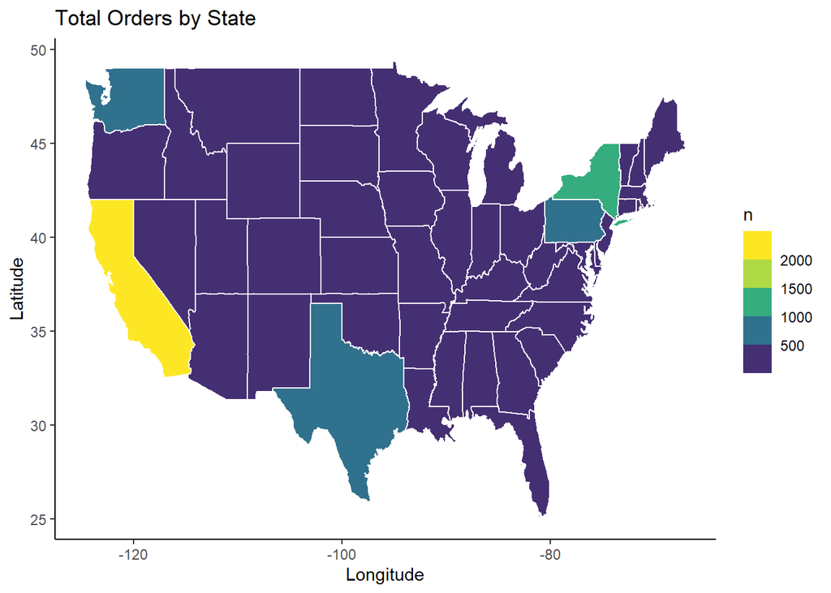

```r
#Total orders by state in descending order
order_by_state <- store %>%
                   group_by(state) %>%
                    tally() %>%
                     arrange(desc(n))

#Create a table with the state map information
state_map <- map_data("state")

#Add a new column "region" to the table
region_tbl <- order_by_state %>%
               mutate(region = tolower(state))

#Left join two tables with the same column "region"
mapdata <- left_join(state_map, region_tbl, by = "region")

#Create a map plot to observe total orders by state
mapdata %>%
  ggplot(aes(long, lat, group = group)) +
  geom_polygon(aes(fill= n), color = 'white') +
  scale_fill_viridis_b(option = 'D') +
  labs(x = "Longitude",
       y = "Latitude",
       title='Total Orders by State') +
  theme_classic()
```

From the map plot, we can observe that California has the highest orders, and New York state with the second highest orders, following by Texas.

## Total Profits by States

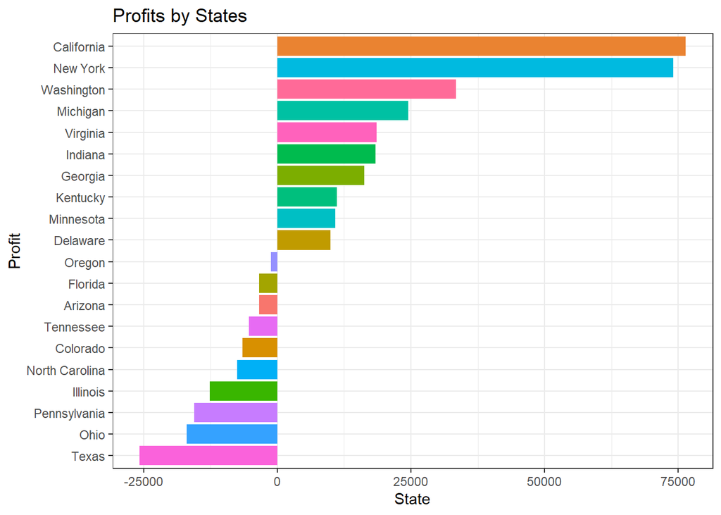

```r
#Calculate total profits by states
state_profit <- store %>%
                 group_by(state) %>%
                  summarise(total_profit = sum(profit)) %>%
                   arrange(by_group = desc(total_profit))

#Select the top 10 and bottom 10 states
top_bottom_10 <- state_profit[c(1:10, 40:49), ]

#Create a bar plot to observe the 10 most and 10 least profitable states
ggplot(top_bottom_10) +
  aes(x = reorder(state, total_profit), y = total_profit, fill = state) +
  geom_bar(stat='identity') +
  theme_bw() +
  coord_flip() +
  theme(legend.position="none") +
  labs(x = "Profit",
       y = "State",
       title = "Profits by States")
```

California has the highest profits made, following by New York. Orders from Texas are losing money.

## Ship Mode Segment

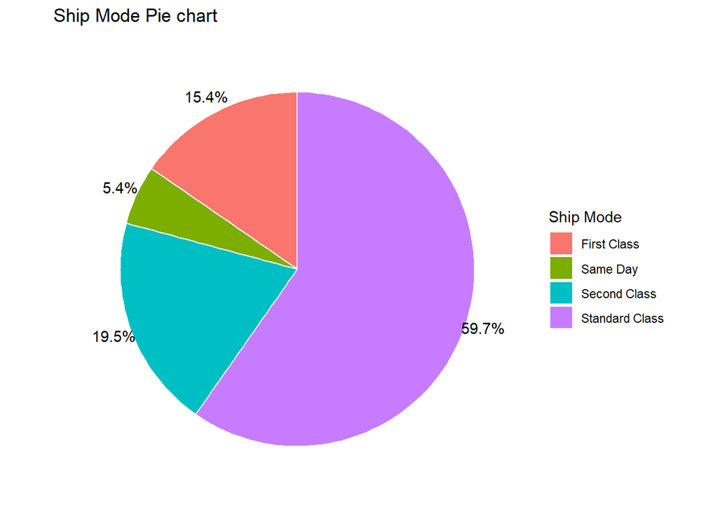

```r
ship_m = store %>%
          group_by(ship_mode) %>%
           tally() %>%
            mutate(perc = n / sum(n))

#Create a pie chart to see percentage of orders by shipping mode
ggplot(ship_m, aes(x = "", y = perc, fill = ship_mode)) +
  geom_bar(width = 1, stat = "identity", color = "white") +
  coord_polar("y", start=0) +
  theme(axis.text.x = element_blank()) +
  geom_text(aes(x = 1.6, label = scales::percent(perc, accuracy = .1)),
            position = position_stack(vjust = .5)) +
  theme_void() +
  labs(title = "Ship Mode Pie chart",
       fill = "Ship Mode")
```

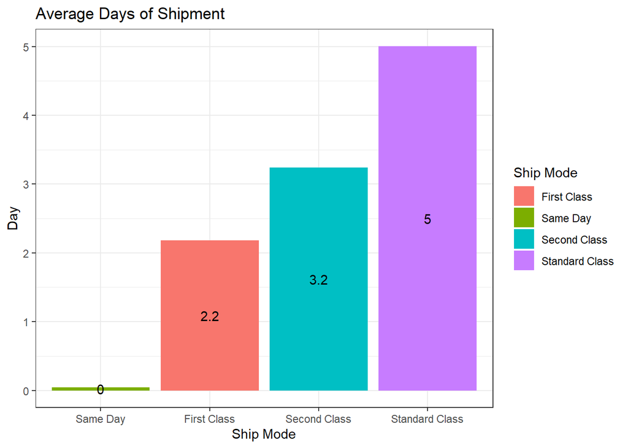

```r
#Convert format of order date to do calculation
store["order_date"] = as.POSIXct(store$order_date,
                                 format="%m/%d/%Y")

#Convert format of ship date to do calculation
store["ship_date"] = as.POSIXct(store$ship_date,
                                format="%m/%d/%Y")

#Calculate average duration of shipment after the order is placed by shipping mode
avg_diff_day <- store %>%
                 mutate(diff_dates = round(difftime(store$ship_date, store$order_date,
                                                    units = "days"), 0)) %>%
                  group_by(ship_mode) %>%
                   summarise(avg_diff_dates = mean(diff_dates))

#Create a bar plot
ggplot(data = avg_diff_day, aes(x = fct_reorder(ship_mode, avg_diff_dates),
                                y = avg_diff_dates, fill = ship_mode)) +
  geom_col() +
  geom_text(aes(label = round(avg_diff_dates, 1)),
            position = position_stack(vjust = 0.5)) +
  theme_bw() +
  labs(x = "Ship Mode",
       y = "Day",
       title = "Average Days of Shipment",
       fill = "Ship Mode")
```

According to the pie chart, approximately 60% of the orders ship mode are standard class, and only 5.4% of the orders ship mode are same day. From the bar plot, we can see that on average, Standard class takes the longest time to ship the orders after consumers order them, whereas same day is the fastest, consumers can have their orders shipped on the same day they ordered them.

# Post-Hoc Analysis

## Category Segment

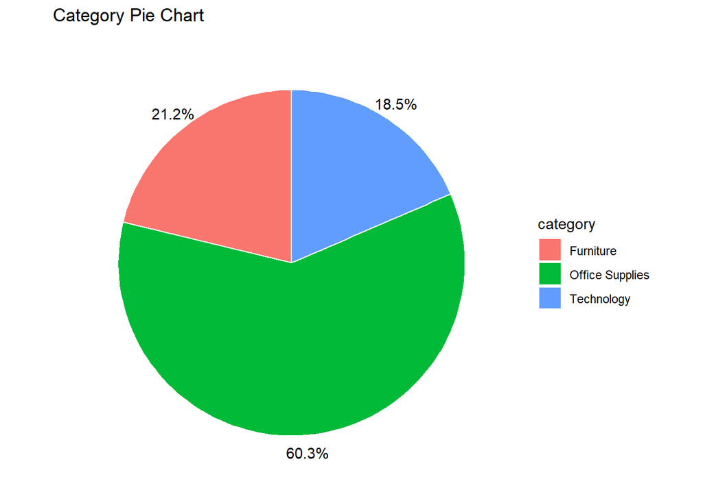

```r
cat <- store %>%
        group_by(category) %>%
         tally() %>%
          mutate(perc = n / sum(n))

ggplot(cat, aes(x = "", y = perc, fill = category)) +
  geom_bar(width = 1, stat = "identity", color = 'white') +
  coord_polar("y", start=0) +
  theme(axis.text.x = element_blank()) +
  geom_text(aes(x = 1.6, label = scales::percent(perc, accuracy = .1)),
            position = position_stack(vjust = .5)) +
  theme_void() +
  labs(title = "Category Pie Chart")
```

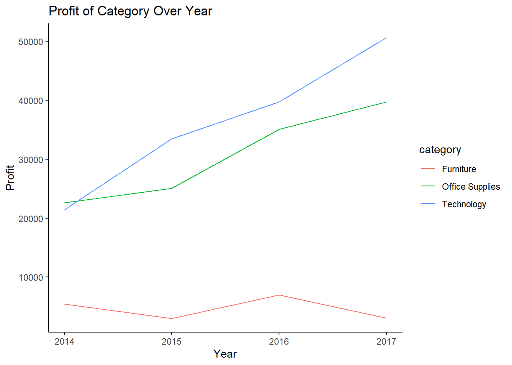

```r
#Extract year of each row and add a new column
store['year'] <- as.numeric(format(store$order_date,'%Y'))

store %>% group_by(category, year) %>%
  summarise(total_profit = sum(profit)) %>%
   ggplot() +
   aes(x = year, y = total_profit, color = category) +
   geom_line() +
   theme_classic() +
   labs(x = "Year",
        y = "Profit",
        title = "Profit of Category Over Year")
```

From the pie chart we can observe that 60.3% of the orders category are office supplies, following by furniture and technology. According to the line plot, profits made in the technology and office supplies category is high and is increasing over time, but profits made in the furniture category is low and decreases in 2015 and 2017.

## Sub-Category Segment

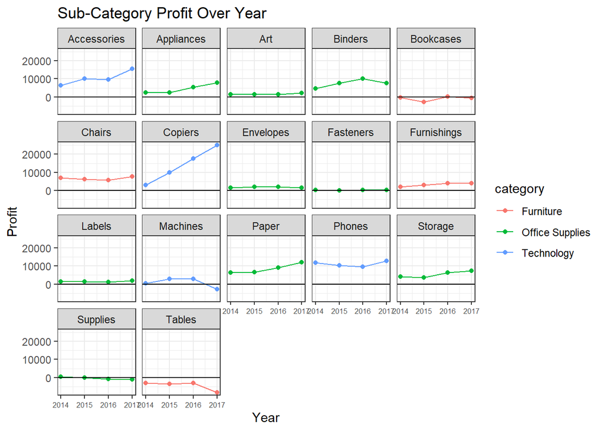

```r
store %>% group_by(category, sub_category, year) %>%
  summarise(profit_cat_year = sum(profit)) %>%
   ggplot() +
   aes(x = year, y = profit_cat_year, color = category) +
   geom_point() +
   geom_line() +
   geom_hline(yintercept = 0) +
   facet_wrap(~ sub_category) +
   theme_bw() +
   theme(axis.text.x=element_text(size = 6)) +
   labs(x = "Year",
        y = "Profit",
        title = "Sub-Category Profit Over Year")
```

Profit made by accessories and copiers have a growing tendency, and both of them belong to the technology category. However, tables have a negative profit over time.

## Discount Segment

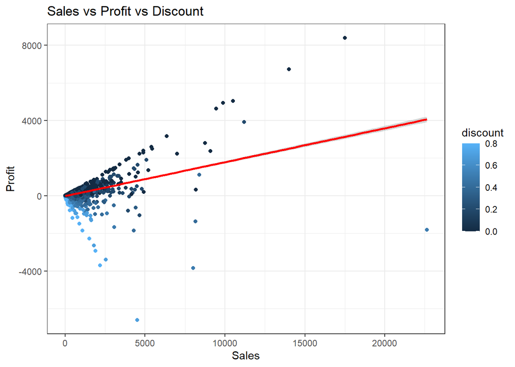

```r
ggplot(store) + aes(x = sales, y = profit, color = discount) +
  geom_point() +
  geom_smooth(method = "lm", color = "red") +
  theme_bw() +
  labs(x = "Sales",
       y = "Profit",
       title = "Sales vs Profit vs Discount")
```

According to the scatterplot, profit increases as sales increases, and profit decreases when discount increases.

# Conclusion

Superstore should focus more on customers located in California and New York states because they have high number of orders while bringing high profits, and might consider avoiding customers from Texas because it has high orders but makes negative profits. Furthermore, superstore should focus more on the technology category, particularly in the accessories and copiers sub-category, although it has the lowest orders among the three categories, it brings the highest total profits and its profit is increasing over year. Finally, excessive discounts on tables sub-category negatively impacts its profit made over year, but superstore should not remove all the products from the tables sub-category because chairs and tables are complementary goods. If customers purchase a table, they may also need to purchase some chairs, and profit made in chairs sub-category is positive and stable.